All cases are based on actual LionBase work

# Case:

FarmX is a company based in Central America that builds bioreactors which can convert wastewater into clean water and algage-based fish feed. Currently, FarmX has dozens of bioreactors. Each day, FarmX collects data on how much feed is produced at each bioreactor, the temperature of the bioreactor, and the nitrate concentration of the water (nitrates stimulate algae growth). They would like to create a model for predicting how much feed is produced at a given bioreactor, as they sell the feed as part of their business model.

To approach this problem, we will use **linear regression** -- a useful and widely used statistical model. **This is often the first type of machine learning that should be tested in any situation.**

Please review Linear Regression - Theory before proceeding with this case.

In this case, we will learn how to:

- Run a linear regression in Python
- Interpret linear regression results
- Identify needs for new features and create them
- Interpret residual plots
- Produce an actionable client deliverable
- Iterate on a model(!!)

## Step 0: Create Dataset for Case

```python
# Create dataset for problem
import numpy as np
import pandas as pd
import random
random.seed(30)
temp_low = np.random.randint(low=-20, high=0, size=300) + np.random.randint(low = 0, high = 100, size = 300)/100
temp_regular = np.random.randint(low=1, high = 34, size = 800) + np.random.randint(low = 0, high = 100, size = 800)/100
temp_high = np.random.randint(low= 35, high = 55, size = 300) + np.random.randint(low = 0, high = 100, size = 300)/100

nitrate_low= np.random.randint(low = 20, high = 100, size = 300)/1000 + np.random.randint(low = 0, high = 100, size = 300)/1000
nitrate_regular = np.random.randint(low = 1, high = 20, size = 800)/1000 + np.random.randint(low = 0, high = 100, size = 800)/1000
nitrate_high = np.random.randint(low = 20, high = 100, size = 300)/1000 + np.random.randint(low = 0, high = 100, size = 300)/1000

feed_low = np.random.randint(low = 0, high = 5, size = 300) + np.random.randint(low = 0, high = 100, size = 300)/100
feed_regular = np.random.randint(low=5, high =10, size = 800) + np.random.randint(low = 0, high = 100, size = 800)/100
feed_high = np.random.randint(low = 0, high =5, size =300) + np.random.randint(low = 0, high = 100, size = 300)/100

all_temp = np.append(temp_low, temp_regular)
all_temp = np.append(all_temp, temp_high)
all_nitrate = np.append(nitrate_low, nitrate_regular)
all_nitrate = np.append(all_nitrate, nitrate_high)
all_feed = np.append(feed_low,feed_regular)
all_feed = np.append(all_feed, feed_high)

dataset = pd.DataFrame({'feed': all_feed, 'temperature': all_temp, 'nitrate': all_nitrate})

shuffled_dataset = dataset.sample(frac=1).reset_index(drop=True)
shuffled_dataset.to_csv('FeedProduction.csv')
```

## Step 1: Import Modules

```python
import numpy as np
import pandas as pd
import scipy as sp
from sklearn import linear_model
import statsmodels.api as sm
import matplotlib.pyplot as plt
import seaborn as sns
```

## Step 2: Read in Data

```python
df = pd.read_csv('FeedProduction.csv')
```

```python
df.describe()
```

|  | Unnamed: 0 | feed | temperature | nitrate |
| --- | --- | --- | --- | --- |
| count | 1400.0000 | 1400.000000 | 1400.000000 | 1400.000000 |
| mean | 699.5000 | 5.324543 | 17.470729 | 0.081885 |
| std | 404.2895 | 2.873896 | 19.747360 | 0.039822 |
| min | 0.0000 | 0.000000 | -19.990000 | 0.002000 |
| 25% | 349.7500 | 2.830000 | 3.117500 | 0.050000 |
| 50% | 699.5000 | 5.650000 | 17.735000 | 0.082000 |
| 75% | 1049.2500 | 7.770000 | 32.200000 | 0.108000 |
| max | 1399.0000 | 9.980000 | 54.680000 | 0.197000 |

```python
df.head()
```

|  | Unnamed: 0 | feed | temperature | nitrate |
| --- | --- | --- | --- | --- |
| 0 | 0 | 9.85 | 16.70 | 0.083 |
| 1 | 1 | 8.24 | 28.25 | 0.100 |
| 2 | 2 | 9.63 | 18.18 | 0.099 |
| 3 | 3 | 9.30 | 9.86 | 0.096 |
| 4 | 4 | 5.91 | 2.23 | 0.082 |

## Step 3: Run a Simple Linear Regression Model

Let's do feed versus nitrate level.

### Using statsmodel

```python
X = df['nitrate']
y = df['feed']
model = sm.OLS(y, X).fit()
model.summary()
```

OLS Regression Results

| Dep. Variable: | feed | R-squared (uncentered): | 0.471 |
| --- | --- | --- | --- |
| Model: | OLS | Adj. R-squared (uncentered): | 0.470 |
| Method: | Least Squares | F-statistic: | 1244. |
| Date: | Sat, 28 Mar 2020 | Prob (F-statistic): | 1.69e-195 |
| Time: | 01:41:28 | Log-Likelihood: | -4061.3 |
| No. Observations: | 1400 | AIC: | 8125. |
| Df Residuals: | 1399 | BIC: | 8130. |
| Df Model: | 1 |  |  |
| Covariance Type: | nonrobust |  |  |

|  | coef | std err | t | P>\|t\| | [0.025 | 0.975] |
| --- | --- | --- | --- | --- | --- | --- |
| nitrate | 45.5890 | 1.293 | 35.271 | 0.000 | 43.054 | 48.125 |

| Omnibus: | 437.186 | Durbin-Watson: | 1.728 |
| --- | --- | --- | --- |
| Prob(Omnibus): | 0.000 | Jarque-Bera (JB): | 82.408 |
| Skew: | -0.270 | Prob(JB): | 1.27e-18 |
| Kurtosis: | 1.941 | Cond. No. | 1.00 |

Warnings:  
[1] Standard Errors assume that the covariance matrix of the errors is correctly specified.

### Analyze results

We can interpret the results as follows:

- The p-value (here described as Prob (F-statistic)) is low meaning that the model is significant
- The p-value of the Nitrate coefficient (here described as P>|t|) is low meaning that the coefficient is significant
- The coefficient of Nitrate is positive, meaning that as nitrate levels increase, feed levels increase
- The Adjusted R^2 value is relatively high, meaning a fair amount of variability is explained by the model

Does this make sense?

- **This makes sense**, as more nitrates should create more algae feed to be produced.

However, can we keep improving?

## Step 4: Add more explanatory variables!

Now this is a multiple linear regression.

### Using statsmodel

```python
X = df[['nitrate', 'temperature']]
y = df['feed']
model = sm.OLS(y, X).fit()
model.summary()
```

OLS Regression Results

| Dep. Variable: | feed | R-squared (uncentered): | 0.520 |
| --- | --- | --- | --- |
| Model: | OLS | Adj. R-squared (uncentered): | 0.519 |
| Method: | Least Squares | F-statistic: | 756.4 |
| Date: | Sat, 28 Mar 2020 | Prob (F-statistic): | 2.29e-223 |
| Time: | 01:41:28 | Log-Likelihood: | -3993.2 |
| No. Observations: | 1400 | AIC: | 7990. |
| Df Residuals: | 1398 | BIC: | 8001. |
| Df Model: | 2 |  |  |
| Covariance Type: | nonrobust |  |  |

|  | coef | std err | t | P>\|t\| | [0.025 | 0.975] |
| --- | --- | --- | --- | --- | --- | --- |
| nitrate | 34.6971 | 1.532 | 22.643 | 0.000 | 31.691 | 37.703 |
| temperature | 0.0632 | 0.005 | 11.948 | 0.000 | 0.053 | 0.074 |

| Omnibus: | 163.625 | Durbin-Watson: | 1.740 |
| --- | --- | --- | --- |
| Prob(Omnibus): | 0.000 | Jarque-Bera (JB): | 83.141 |
| Skew: | -0.437 | Prob(JB): | 8.84e-19 |
| Kurtosis: | 2.187 | Cond. No. | 360. |

Warnings:  
[1] Standard Errors assume that the covariance matrix of the errors is correctly specified.

### Analyze Results

We can interpret the results as follows:

- This model is a slightly better predictor than the previous model as the p-value for the F-statistic is lower than before and the Adj. R-squared value is higher than before. However, the F-statistic itself has decreased.
- Both Nitrate and Temperature are statistically significant as the p-value is less than 0.05 for both cases
- Both Nitrate and Temperature are positively correlated with Feed

Does this make sense?

- This still makes sense. More nitrates and higher temperatures should lead to greater algae feed production.

At this point, we have exhausted all available variables. However, we are still not explaining the variability in the data well. How can we do better?

## Step 5: Create New Variables

Let's see if there's a pattern we're missing in the explanatory variables by plotting temperature and nitrate against each other.

### Using matplotlib.pyplot as plt

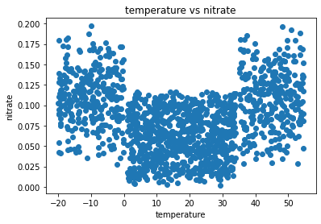

```python
x = np.array(df['temperature'])
y = np.array(df['nitrate'])
plt.scatter(x, y)
plt.title('temperature vs nitrate')
plt.xlabel('temperature')
plt.ylabel('nitrate')
plt.show()
```

### Analyze Results

There are clearly higher nitrate levels at more extreme temperatures. Let's make a binary variable out of this, where 1 indicates an extreme temperature and 0 indicates a regular temperature.

```python
df['extreme_temp'] = [1 if x <= 0 or x >= 35 else 0 for x in df['temperature']]
df.head()
```

|  | Unnamed: 0 | feed | temperature | nitrate | extreme_temp |
| --- | --- | --- | --- | --- | --- |
| 0 | 0 | 9.85 | 16.70 | 0.083 | 0 |
| 1 | 1 | 8.24 | 28.25 | 0.100 | 0 |
| 2 | 2 | 9.63 | 18.18 | 0.099 | 0 |
| 3 | 3 | 9.30 | 9.86 | 0.096 | 0 |
| 4 | 4 | 5.91 | 2.23 | 0.082 | 0 |

## Step 6: Rerun Regression with New Variable

### Using statsmodels

```python
X = df[['nitrate', 'temperature', 'extreme_temp']]
y = df['feed']
model = sm.OLS(y, X).fit()
model.summary()
```

OLS Regression Results

| Dep. Variable: | feed | R-squared (uncentered): | 0.701 |
| --- | --- | --- | --- |
| Model: | OLS | Adj. R-squared (uncentered): | 0.700 |
| Method: | Least Squares | F-statistic: | 1090. |
| Date: | Sat, 28 Mar 2020 | Prob (F-statistic): | 0.00 |
| Time: | 01:41:28 | Log-Likelihood: | -3662.4 |
| No. Observations: | 1400 | AIC: | 7331. |
| Df Residuals: | 1397 | BIC: | 7347. |
| Df Model: | 3 |  |  |
| Covariance Type: | nonrobust |  |  |

|  | coef | std err | t | P>\|t\| | [0.025 | 0.975] |
| --- | --- | --- | --- | --- | --- | --- |
| nitrate | 71.7519 | 1.758 | 40.807 | 0.000 | 68.303 | 75.201 |
| temperature | 0.0559 | 0.004 | 13.339 | 0.000 | 0.048 | 0.064 |
| extreme_temp | -6.3463 | 0.218 | -29.051 | 0.000 | -6.775 | -5.918 |

| Omnibus: | 16.853 | Durbin-Watson: | 1.771 |
| --- | --- | --- | --- |
| Prob(Omnibus): | 0.000 | Jarque-Bera (JB): | 17.308 |
| Skew: | -0.267 | Prob(JB): | 0.000174 |
| Kurtosis: | 2.894 | Cond. No. | 525. |

Warnings:  
[1] Standard Errors assume that the covariance matrix of the errors is correctly specified.

## Step 7: Plot the Residuals

Residuals plot the difference between fitted values (the predictions) and the actual values. The center dotted line represents (in this case) the best-fit line. The data points around the line indicate the actual values and how far away from the best-fit line they are.

### We first need to get the predicted values

```python
X = df[['nitrate', 'temperature', 'extreme_temp']]
y = df['feed']
model = sm.OLS(y, X).fit()
predictions = model.predict(X)
```

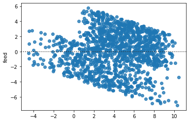

```python
sns.residplot(predictions, y)
plt.show()
```

### Analyze Results

Looking at the above, there is non-linearity in the residuals. In specific, there appears to be a downward curve to the residuals.

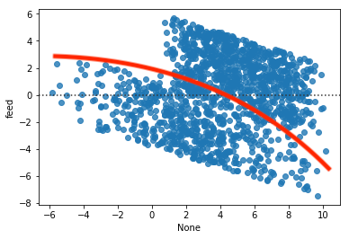

```python
from IPython.display import Image
Image('residuals_case.png')
```

This indicates that we are likely not using an important non-linear independent variable.

Because of the shape of the curve, it appears we need to add a log(X) feature. Which feature should we transform?

```python
df.describe()
```

|  | Unnamed: 0 | feed | temperature | nitrate | extreme_temp |
| --- | --- | --- | --- | --- | --- |
| count | 1400.0000 | 1400.000000 | 1400.000000 | 1400.000000 | 1400.000000 |
| mean | 699.5000 | 5.324543 | 17.470729 | 0.081885 | 0.428571 |
| std | 404.2895 | 2.873896 | 19.747360 | 0.039822 | 0.495048 |
| min | 0.0000 | 0.000000 | -19.990000 | 0.002000 | 0.000000 |
| 25% | 349.7500 | 2.830000 | 3.117500 | 0.050000 | 0.000000 |
| 50% | 699.5000 | 5.650000 | 17.735000 | 0.082000 | 0.000000 |
| 75% | 1049.2500 | 7.770000 | 32.200000 | 0.108000 | 1.000000 |
| max | 1399.0000 | 9.980000 | 54.680000 | 0.197000 | 1.000000 |

Looking at the above, the only feature we should try to apply a log transformation on is the nitrate feature.

- This is because temperature has negative values (see minimum value), which we cannot take the log of
- The minimum value for nitrate is greater than zero, which means that all nitrate values are positive and we can take the log of it

## Step 8: Rerun Regression with New Log Variable

### Add log_nitrate feature

```python
df['log_nitrate'] = np.log(df['nitrate'])
df.head()
```

|  | Unnamed: 0 | feed | temperature | nitrate | extreme_temp | log_nitrate |
| --- | --- | --- | --- | --- | --- | --- |
| 0 | 0 | 9.85 | 16.70 | 0.083 | 0 | -2.488915 |
| 1 | 1 | 8.24 | 28.25 | 0.100 | 0 | -2.302585 |
| 2 | 2 | 9.63 | 18.18 | 0.099 | 0 | -2.312635 |
| 3 | 3 | 9.30 | 9.86 | 0.096 | 0 | -2.343407 |
| 4 | 4 | 5.91 | 2.23 | 0.082 | 0 | -2.501036 |

### Re-run model with log_nitrate feature

```python
X = df[['nitrate', 'temperature', 'extreme_temp', 'log_nitrate']]
y = df['feed']
model = sm.OLS(y, X).fit()
model.summary()
```

OLS Regression Results

| Dep. Variable: | feed | R-squared (uncentered): | 0.936 |
| --- | --- | --- | --- |
| Model: | OLS | Adj. R-squared (uncentered): | 0.936 |
| Method: | Least Squares | F-statistic: | 5102. |
| Date: | Sat, 28 Mar 2020 | Prob (F-statistic): | 0.00 |
| Time: | 01:41:28 | Log-Likelihood: | -2582.7 |
| No. Observations: | 1400 | AIC: | 5173. |
| Df Residuals: | 1396 | BIC: | 5194. |
| Df Model: | 4 |  |  |
| Covariance Type: | nonrobust |  |  |

|  | coef | std err | t | P>\|t\| | [0.025 | 0.975] |
| --- | --- | --- | --- | --- | --- | --- |
| nitrate | 30.6399 | 0.995 | 30.779 | 0.000 | 28.687 | 32.593 |
| temperature | 0.0034 | 0.002 | 1.640 | 0.101 | -0.001 | 0.007 |
| extreme_temp | -5.1577 | 0.102 | -50.363 | 0.000 | -5.359 | -4.957 |
| log_nitrate | -1.8521 | 0.026 | -71.639 | 0.000 | -1.903 | -1.801 |

| Omnibus: | 391.595 | Durbin-Watson: | 1.987 |
| --- | --- | --- | --- |
| Prob(Omnibus): | 0.000 | Jarque-Bera (JB): | 63.871 |
| Skew: | -0.001 | Prob(JB): | 1.35e-14 |
| Kurtosis: | 1.954 | Cond. No. | 644. |

Warnings:  
[1] Standard Errors assume that the covariance matrix of the errors is correctly specified.

### Analyze Results

We can interpret the above as follows:

- There is a big increase in the Adjusted R^2 value and the model remains statistically significant as the p-value is less than 0.05 for the high F-statistic
- In fact, the Adj. R^2 value is nearly 1! Which means now nearly all variability of the data is explained by this model
- Interestingly, the p-value for temperature is now greater than 0.05, which means it is not significant

Let's try removing the temperature variable now that it is no longer significant in this model.

## Step 9: Rerun Regression with Reduced Feature Set

```python
X = df[['nitrate', 'extreme_temp', 'log_nitrate']]
y = df['feed']
model = sm.OLS(y, X).fit()
model.summary()
```

OLS Regression Results

| Dep. Variable: | feed | R-squared (uncentered): | 0.936 |
| --- | --- | --- | --- |
| Model: | OLS | Adj. R-squared (uncentered): | 0.936 |
| Method: | Least Squares | F-statistic: | 6794. |
| Date: | Sat, 28 Mar 2020 | Prob (F-statistic): | 0.00 |
| Time: | 01:41:28 | Log-Likelihood: | -2584.0 |
| No. Observations: | 1400 | AIC: | 5174. |
| Df Residuals: | 1397 | BIC: | 5190. |
| Df Model: | 3 |  |  |
| Covariance Type: | nonrobust |  |  |

|  | coef | std err | t | P>\|t\| | [0.025 | 0.975] |
| --- | --- | --- | --- | --- | --- | --- |
| nitrate | 30.8719 | 0.986 | 31.312 | 0.000 | 28.938 | 32.806 |
| extreme_temp | -5.1574 | 0.102 | -50.331 | 0.000 | -5.358 | -4.956 |
| log_nitrate | -1.8671 | 0.024 | -77.161 | 0.000 | -1.915 | -1.820 |

| Omnibus: | 385.708 | Durbin-Watson: | 1.990 |
| --- | --- | --- | --- |
| Prob(Omnibus): | 0.000 | Jarque-Bera (JB): | 63.555 |
| Skew: | -0.009 | Prob(JB): | 1.58e-14 |
| Kurtosis: | 1.956 | Cond. No. | 66.7 |

Warnings:  
[1] Standard Errors assume that the covariance matrix of the errors is correctly specified.

### Analyze Results

We can interpret the above as follows:

- The Adj. R^2 value had negligble change, which means that the continuous temperature variable was not contributing to the model
- This means that it is only important for us to note whether or not a temperature is within an extreme range

## Step 10: Re-plot the Residuals

```python
X = df[['nitrate', 'extreme_temp', 'log_nitrate']]
y = df['feed']
model = sm.OLS(y, X).fit()
predictions = model.predict(X)
```

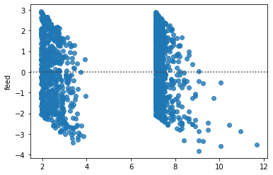

```python
sns.residplot(predictions, y)
plt.show()
```

### Analyze Results

The residuals now have a more random pattern, though they appear in two main clusters. Recall that we are working with a binary variable (extreme_temp) that indicates whether or not the temperature reading of a bioreactor is in an extreme state.

- The two clusters may indicate that we get significantly different feed output results in each range
- Let's verify this before we consider making more changes to the model

## Step 11: Investigate Clusters

```python
df_extreme = df[df['extreme_temp'] == 1]
df_regular = df[df['extreme_temp'] == 0]
```

```python
df_extreme.describe()
```

|  | Unnamed: 0 | feed | temperature | nitrate | extreme_temp | log_nitrate |
| --- | --- | --- | --- | --- | --- | --- |
| count | 600.000000 | 600.000000 | 600.000000 | 600.000000 | 600.0 | 600.000000 |
| mean | 676.673333 | 2.461267 | 17.571000 | 0.109070 | 1.0 | -2.277043 |
| std | 402.789062 | 1.471172 | 28.060616 | 0.035068 | 0.0 | 0.370872 |
| min | 6.000000 | 0.000000 | -19.990000 | 0.028000 | 1.0 | -3.575551 |
| 25% | 334.750000 | 1.140000 | -9.562500 | 0.084750 | 1.0 | -2.468063 |
| 50% | 682.500000 | 2.360000 | 17.510000 | 0.110000 | 1.0 | -2.207275 |
| 75% | 1021.250000 | 3.715000 | 45.155000 | 0.134000 | 1.0 | -2.009915 |
| max | 1399.000000 | 4.990000 | 54.680000 | 0.197000 | 1.0 | -1.624552 |

```python
df_regular.describe()
```

|  | Unnamed: 0 | feed | temperature | nitrate | extreme_temp | log_nitrate |
| --- | --- | --- | --- | --- | --- | --- |
| count | 800.000000 | 800.000000 | 800.000000 | 800.000000 | 800.0 | 800.000000 |
| mean | 716.620000 | 7.472000 | 17.395525 | 0.061496 | 0.0 | -2.956468 |
| std | 404.818077 | 1.437048 | 9.616521 | 0.029722 | 0.0 | 0.654924 |
| min | 0.000000 | 5.010000 | 1.050000 | 0.002000 | 0.0 | -6.214608 |
| 25% | 363.500000 | 6.187500 | 9.297500 | 0.036000 | 0.0 | -3.324236 |
| 50% | 716.500000 | 7.430000 | 17.735000 | 0.062000 | 0.0 | -2.780621 |
| 75% | 1067.500000 | 8.730000 | 25.715000 | 0.086000 | 0.0 | -2.453408 |
| max | 1398.000000 | 9.980000 | 33.920000 | 0.116000 | 0.0 | -2.154165 |

### Analyze Results

Looking at the feed column of each dataset description:

- The feed production at non-extreme temperatures is between 5 and 10
- The feed production at extreme temperatures is between 0 and 5

From, this we can now make a **data-backed recommendation**:

## Step 12: Summarize the Client Deliverable!

### Model Deliverable

The client can use this model to predict algae feed production in their bioreactors.

```python
df = pd.read_csv('FeedProduction.csv')
df['extreme_temp'] = [1 if x <= 0 or x >= 35 else 0 for x in df['temperature']]
df['log_nitrate'] = np.log(df['nitrate'])
X = df[['nitrate', 'extreme_temp', 'log_nitrate']]
y = df['feed']
model = sm.OLS(y, X).fit()
model.summary()
```

OLS Regression Results

| Dep. Variable: | feed | R-squared (uncentered): | 0.936 |
| --- | --- | --- | --- |
| Model: | OLS | Adj. R-squared (uncentered): | 0.936 |
| Method: | Least Squares | F-statistic: | 6794. |
| Date: | Sat, 28 Mar 2020 | Prob (F-statistic): | 0.00 |
| Time: | 01:41:28 | Log-Likelihood: | -2584.0 |
| No. Observations: | 1400 | AIC: | 5174. |
| Df Residuals: | 1397 | BIC: | 5190. |
| Df Model: | 3 |  |  |
| Covariance Type: | nonrobust |  |  |

|  | coef | std err | t | P>\|t\| | [0.025 | 0.975] |
| --- | --- | --- | --- | --- | --- | --- |
| nitrate | 30.8719 | 0.986 | 31.312 | 0.000 | 28.938 | 32.806 |
| extreme_temp | -5.1574 | 0.102 | -50.331 | 0.000 | -5.358 | -4.956 |
| log_nitrate | -1.8671 | 0.024 | -77.161 | 0.000 | -1.915 | -1.820 |

| Omnibus: | 385.708 | Durbin-Watson: | 1.990 |
| --- | --- | --- | --- |
| Prob(Omnibus): | 0.000 | Jarque-Bera (JB): | 63.555 |
| Skew: | -0.009 | Prob(JB): | 1.58e-14 |
| Kurtosis: | 1.956 | Cond. No. | 66.7 |

Warnings:  
[1] Standard Errors assume that the covariance matrix of the errors is correctly specified.

### Actionable Insight Deliverable

# Conclusion

In this case, we learned how to:

- Run a linear regression in Python
- Interpret linear regression results
- Identify needs for new features and create them
- Interpret residual plots
- Produce an actionable client deliverable
- **Iterate on a model**

The last bulletpoint is the key takeaway. The final deliverable is very concise, but it took a lot of iteration and analysis to get there. Although the final deliverable is concise, it actually has huge ramifications for FarmX.

And because the final deliverable is concise, it is easy to communicate and apply. A deliverable that cannot be understood is a deliverable that will never be used, no matter how well it actually works.

Additionally, consider how little we actually coded. Coding is a tool for data science and data analytics, but at its core data science is an understanding of math (which is why it is important to learn the theory!). It is easy to run a model -- even something as complex as a neural net -- but it is more important to understand how to do it right and when to apply certain methods. As you've hopefully seen, something as fundamental as linear regression can be quite extensive and powerful.